# Least Squares Estimation- Week 1

Galton data and the regression line seen in the Introduction. The regression line summarizes the relationship between parents’ heights (the predictors) and their children’s (the outcomes).

The regression line is the line through the data which has the minimum (least) squared “error”.

Squaring the distances ensures that data points above and below the line are treated the same. This method of choosing the ‘best’ regression line (or ‘fitting’ a line to the data) is known as ordinary least squares.

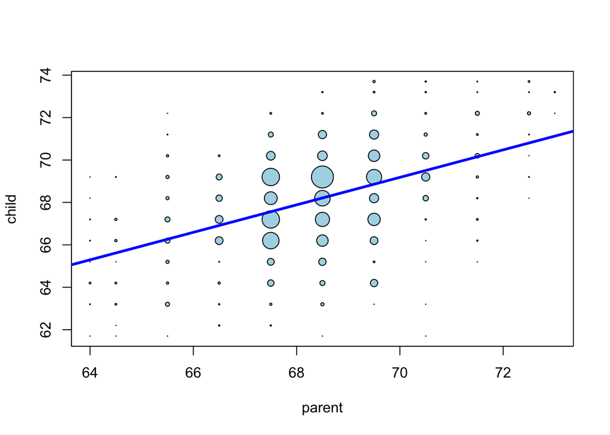

The regression line contains the point representing the means of the two sets of heights. These are shown by the thin horizontal and vertical lines. The intersection point is shown by the triangle on the plot. Its x-coordinate is the mean of the parents’ heights and y-coordinate is the mean of the childrens’ heights.

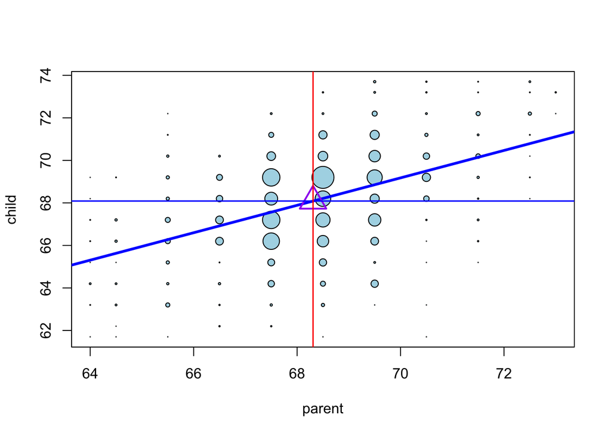

The slope of the regression line is the correlation between the two sets of heights multiplied by the ratio of the standard deviations (childrens’ to parents’ or outcomes to predictors). Changing the slope of the regression line affects the mean squared error between actual and predicted values.

Data normalization is performed by subtracting its mean and dividing by its standard deviation.

```r
gch <- galton$child
gpa <- galton$parent
gpa_nor <- (gpa - mean(gpa))/sd(gpa)
gch_nor <- (gch - mean(gch))/sd(gch)

# correlation between the normalized data sets
cor(gpa_nor, gch_nor)
```

```
[1] 0.4587624
```

```r
# generate the regression line using this normalized data
l_nor <- lm(gch_nor ~ gpa_nor)
summary(l_nor)
```

```
Call:
lm(formula = gch_nor ~ gpa_nor)

Residuals:
     Min       1Q   Median       3Q      Max
-3.09976 -0.54256  0.01934  0.64889  2.35368

Coefficients:
             Estimate Std. Error t value Pr(>|t|)
(Intercept) 2.990e-15  2.918e-02    0.00        1
gpa_nor     4.588e-01  2.920e-02   15.71   <2e-16 ***
---
Signif. codes:  0 '***' 0.001 '**' 0.01 '*' 0.05 '.' 0.1 ' ' 1

Residual standard error: 0.889 on 926 degrees of freedom
Multiple R-squared:  0.2105,    Adjusted R-squared:  0.2096
F-statistic: 246.8 on 1 and 926 DF,  p-value: < 2.2e-16
```

Plot of Galton data with three regression lines, the original in red with the children as the outcome, a new blue line with the parents’ as outcome and childrens’ as predictor, and a black line with the slope scaled so it equals the ratio of the standard deviations.

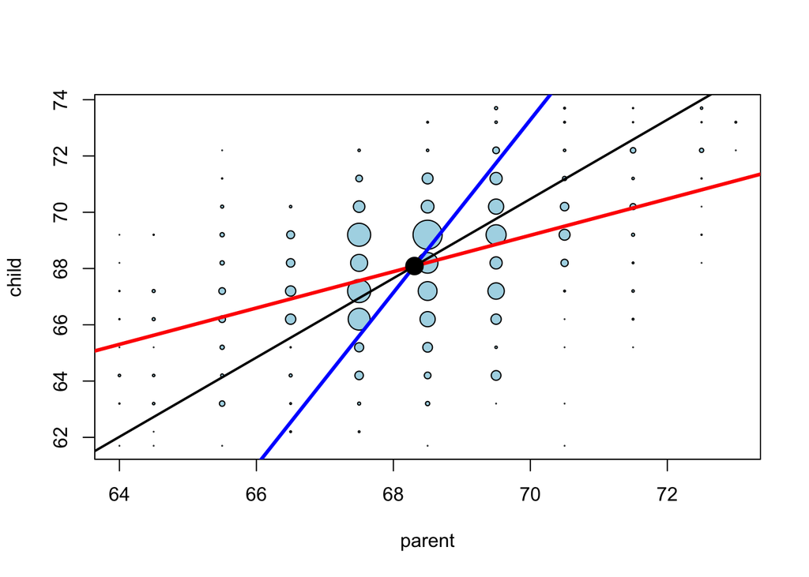

```r
#plot the original Galton data points with larger dots for more freq pts
y <- galton$child
x <- galton$parent
freqData <- as.data.frame(table(galton$child, galton$parent))
names(freqData) <- c("child", "parent", "freq")
plot(as.numeric(as.vector(freqData$parent)),
     as.numeric(as.vector(freqData$child)),
     pch = 21, col = "black", bg = "lightblue",
     cex = .07 * freqData$freq, xlab = "parent", ylab = "child")

#original regression line, children as outcome, parents as predictor
abline(mean(y) - mean(x) * cor(y, x) * sd(y) / sd(x), #intercept
       sd(y) / sd(x) * cor(y, x),  #slope
       lwd = 3, col = "red")

#new regression line, parents as outcome, children as predictor
abline(mean(y) - mean(x) * sd(y) / sd(x) / cor(y, x), #intercept
       sd(y) / cor(y, x) / sd(x), #slope
       lwd = 3, col = "blue")

#assume correlation is 1 so slope is ratio of std deviations
abline(mean(y) - mean(x) * sd(y) / sd(x), #intercept
       sd(y) / sd(x),  #slope
       lwd = 2)
points(mean(x), mean(y), cex = 2, pch = 19) #big point of intersection
```